# On the waning of forms - a corpus-based analysis of losers in language change (Part 3)

## Diagnostics

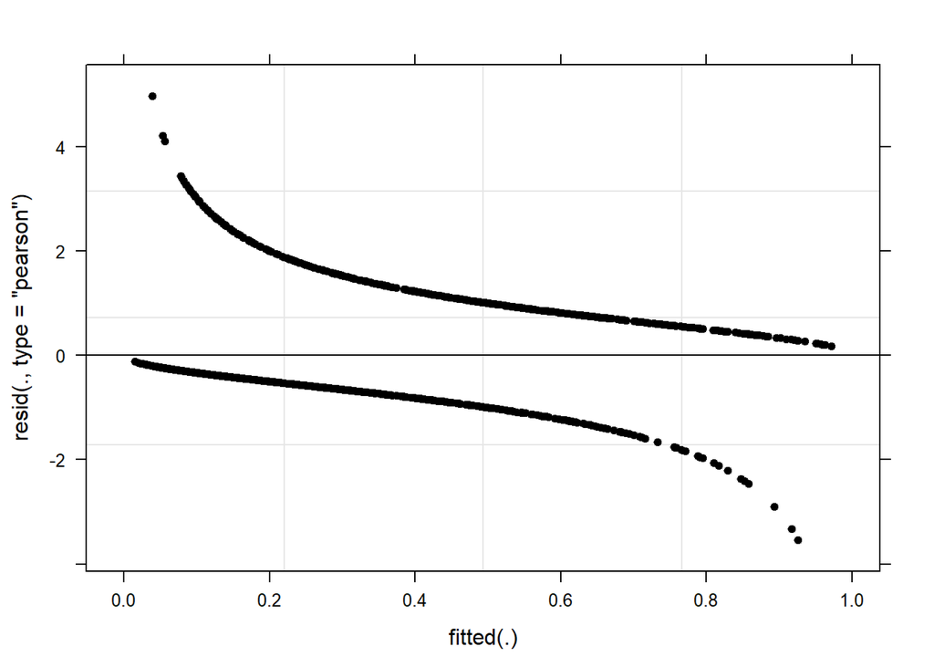

```r
plot(m58.glmer, col = "black", pch = 20); par(mfrow = c(1, 1))
```

## Model fitting summary

In a next step, we create a summary of the model fitting process.

```r
# use customized model comparison function
# create compariveryns
m1m0 <- anova(m0.glmer, m1.glmer, test = "Chi")
m2m1 <- anova(m2.glmer, m1.glmer, test = "Chi")
m3m1 <- anova(m3.glmer, m1.glmer, test = "Chi")
m4m3 <- anova(m4.glmer, m3.glmer, test = "Chi")
m5m4 <- anova(m5.glmer, m4.glmer, test = "Chi")
m6m5 <- anova(m6.glmer, m5.glmer, test = "Chi")
m7m6 <- anova(m7.glmer, m6.glmer, test = "Chi")
m8m6 <- anova(m8.glmer, m6.glmer, test = "Chi")
m9m6 <- anova(m9.glmer, m6.glmer, test = "Chi")
m10m6 <- anova(m10.glmer, m6.glmer, test = "Chi")
m13m10 <- anova(m13.glmer, m10.glmer, test = "Chi")
m14m10 <- anova(m14.glmer, m10.glmer, test = "Chi")
m20m14 <- anova(m20.glmer, m14.glmer, test = "Chi")
m31m14 <- anova(m31.glmer, m14.glmer, test = "Chi")
m33m14 <- anova(m33.glmer, m14.glmer, test = "Chi")
m34m33 <- anova(m34.glmer, m33.glmer, test = "Chi")
m35m33 <- anova(m35.glmer, m33.glmer, test = "Chi")
m36m33 <- anova(m36.glmer, m33.glmer, test = "Chi")
m41m33 <- anova(m41.glmer, m33.glmer, test = "Chi")
m44m41 <- anova(m44.glmer, m41.glmer, test = "Chi")
m58m41 <- anova(m58.glmer, m41.glmer, test = "Chi")
m59m58 <- anova(m59.glmer, m58.glmer, test = "Chi")
m64m58 <- anova(m64.glmer, m58.glmer, test = "Chi")

# create a list of the model compariveryns
mdlcmp <- list(m1m0, m2m1, m3m1, m4m3, m5m4, m6m5, m7m6, m8m6, m9m6, m10m6, m13m10,
               m14m10, m20m14, m31m14, m33m14, m34m33, m35m33, m36m33, m41m33, m44m41,
               m58m41, m59m58, m64m58)
# load function
source("D:\\R/ModelFittingSummarySWSU.R") # for Mixed Effects Model fitting (step-wise step-up): Binary Logistic Mixed Effects Models
# apply function
mdl.cmp.glmersc.swsu.dm <- mdl.fttng.swsu(mdlcmp)
# save comparisons to disc
write.table(mdl.cmp.glmersc.swsu.dm, here::here("data", "mdl_cmp_glmersc_swsu_verywscnew.txt"), sep="\t")
# inspect output
mdl.cmp.glmersc.swsu.dm
```

```
##        Model
## 1   m1.glmer
## 2   m2.glmer
## 3   m3.glmer
## 4   m4.glmer
## 5   m5.glmer
## 6   m6.glmer
## 7   m7.glmer
## 8   m8.glmer
## 9   m9.glmer
## 10 m10.glmer
## 11 m13.glmer
## 12 m14.glmer
## 13 m20.glmer
## 14 m31.glmer
```

[output cut: 81 more lines]

# 5 Model summary

```r
m58.glm <-  glm(very ~ Age + Priming + Emotionality + Type + Gender + Education + Age:Priming + Gender:Education,
                family = "binomial", data = verywsc)
```

```r
# load function for regression table summary
source("D:\\R/meblr.summary.R")
# set up summary table
meblrm_ampwsc <- meblrm.summary(m0.glm, m58.glm, m0.glmer, m58.glmer, verywsc$very)
# save results to disc
write.table(meblrm_ampwsc, here::here("data", "meblrm_ampwsc.txt"), sep="\t")
# inspect result summary
meblrm_ampwsc
```

```
##                                  Group(s) Variance Std. Dev.
## Random Effect(s)                Adjective     0.76      0.87
## Fixed Effect(s)                  Estimate      VIF OddsRatio CI(2.5%) CI(97.5%)
## (Intercept)                         -1.69               0.18     0.12      0.29
## Age30-39                             0.84     1.47      2.31     1.61      3.31
## Age40+                               1.58     1.54      4.85     3.64      6.45
## PrimingPrime                        -0.27     1.89      0.76     0.49      1.19
## TypePrivate                          0.01     2.26      1.01      0.7      1.46
## TypePublic                           0.88     2.16      2.41     1.58      3.67
## GenderWoman                         -0.78      2.4      0.46     0.32      0.65
## EducationUniversity                 -0.22     2.37       0.8     0.57      1.13
## Age30-39:PrimingPrime                0.61     1.51      1.84     0.75      4.49
## Age40+:PrimingPrime                  2.18     1.59      8.85      4.1     19.12
## GenderWoman:EducationUniversity      0.66     3.68      1.93     1.22      3.04
## Model statistics
## Number of Groups
## Number of cases in model
## Observed misses
## Observed successes
## Residual deviance
## R2 (Nagelkerke)
## R2 (Hosmer & Lemeshow)
## R2 (Cox & Snell)
## C
## Somers' Dxy
## AIC
## BIC
## Prediction accuracy
## Model Likelihood Ratio Test
##                                         L.R. X2      DF         Pr
## Random Effect(s)                         152.76       1          0
## Fixed Effect(s)                      Std. Error z value   Pr(>|z|)
## (Intercept)                                0.24   -7.11          0
## Age30-39                                   0.18    4.56          0
## Age40+                                     0.15   10.84          0
## PrimingPrime                               0.23   -1.19     0.2323
## TypePrivate                                0.19    0.03     0.9731
## TypePublic                                 0.22    4.07          0
## GenderWoman                                0.18   -4.43          0
## EducationUniversity                        0.17   -1.26     0.2093
```

[output cut: 32 more lines]

```
## Model statistics                           Value
## Number of Groups                             420
## Number of cases in model                    2344
## Observed misses                                0
## Observed successes                             0
## Residual deviance                        2218.46
## R2 (Nagelkerke)                            0.408
## R2 (Hosmer & Lemeshow)                     0.282
## R2 (Cox & Snell)                           0.283
## C                                          0.849
## Somers' Dxy                                0.698
## AIC                                      2242.46
## BIC                                      2311.57
## Prediction accuracy                          NA%
## Model Likelihood Ratio Test     sig: p < .001***
```

We also check the Anova summary to see if predictors, rather than individual predictor levels, are significant and to what extent.

```r
# load function
library(car)
meblrm_ampwsc_Anova <- Anova(m58.glmer, type = "III", test = "Chi")
# save results to disc
write.table(meblrm_ampwsc_Anova, here::here("data", "meblrm_ampwsc_Anova.txt") , sep="\t")
# inspect results in Anova style
meblrm_ampwsc_Anova
```

```
## Analysis of Deviance Table (Type III Wald chisquare tests)
##
## Response: very
##                     Chisq Df            Pr(>Chisq)
## (Intercept)       50.5695  1      0.00000000000115 ***
## Age              117.5868  2 < 0.00000000000000022 ***
## Priming            1.4268  1              0.232295
## Type              31.7964  2      0.00000012459412 ***
## Gender            19.6272  1      0.00000941188717 ***
## Education          1.5760  1              0.209343
## Age:Priming       30.8715  2      0.00000019785502 ***
## Gender:Education   7.9486  1              0.004812 **
## ---
## Signif. codes:  0 '***' 0.001 '**' 0.01 '*' 0.05 '.' 0.1 ' ' 1
```

Visualize effects

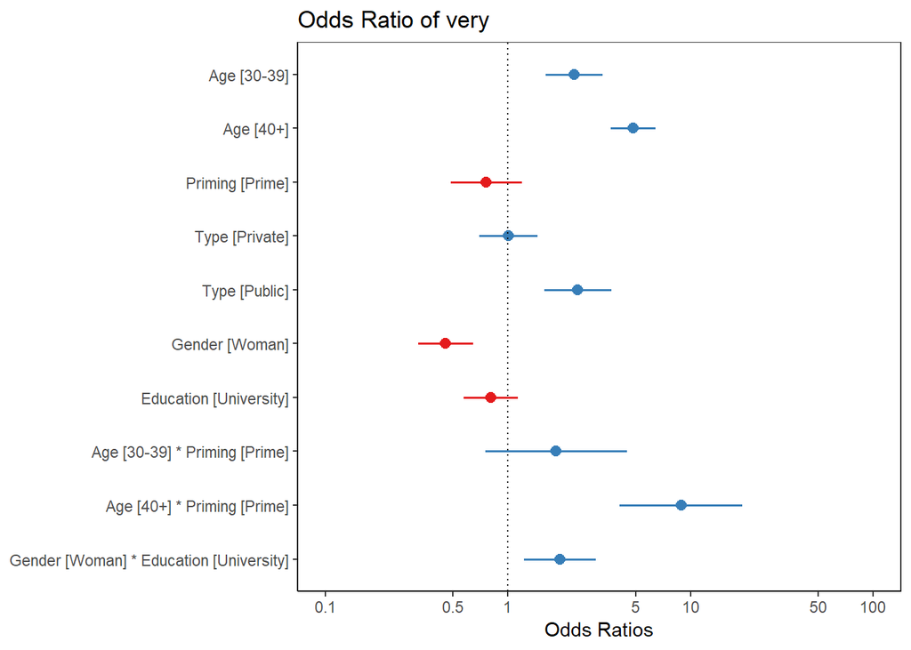

```r
sjPlot::plot_model(m58.glmer) +
  theme_bw() +
  geom_hline(yintercept = 1, linetype = "dotted") +
  theme(legend.position = "top",
        panel.grid.major = element_blank(),
        panel.grid.minor = element_blank(),
        axis.line = element_line(colour = "black")) +
  labs(title = "Odds Ratio of very")+
  ggsave(file =  here::here("images", "Effects.png"),
         width = 20, height = 10, units = c("cm"),  dpi = 600)
```

```r
sjPlot::tab_model(m0.glmer, m1.glmer, m58.glmer,
                  dv.labels = c("Intercept-only Model", "Age-only Model", "Final Minimal Model"),
                  p.style = "stars", collapse.ci = TRUE)
```

Intercept-only Model

Age-only Model

Final Minimal Model

Predictors

Odds Ratios

Odds Ratios

Odds Ratios

(Intercept)

0.37 ***  
(0.30 – 0.44)

0.14 ***  
(0.11 – 0.17)

0.18 ***  
(0.12 – 0.29)

Age30-39

2.72 ***  
(1.98 – 3.73)

2.31 ***  
(1.61 – 3.31)

Age [40+]

7.40 ***  
(5.79 – 9.45)

4.85 ***  
(3.64 – 6.45)

Priming [Prime]

0.76  
(0.49 – 1.19)

Type [Private]

1.01  
(0.70 – 1.46)

Type [Public]

2.41 ***  
(1.58 – 3.67)

Gender [Woman]

0.46 ***  
(0.32 – 0.65)

Education [University]

0.80  
(0.57 – 1.13)

Age30-39:PrimingPrime

1.84  
(0.75 – 4.49)

Age [40+] * Priming  
[Prime]

8.85 ***  
(4.10 – 19.12)

Gender [Woman] *  
Education [University]

1.93 **  
(1.22 – 3.04)

Random Effects

σ<sup>2</sup>

3.29

3.29

3.29

τ<sub>00</sub>

1.23 <sub>Adjective</sub>

0.82 <sub>Adjective</sub>

0.76 <sub>Adjective</sub>

ICC

0.27

0.20

0.19

N

420 <sub>Adjective</sub>

420 <sub>Adjective</sub>

420 <sub>Adjective</sub>

Observations

2344

2344

2344

Marginal R<sup>2</sup> / Conditional R<sup>2</sup>

0.000 / 0.273

0.164 / 0.331

0.236 / 0.379

- p<0.05 ** p<0.01 *** p<0.001

## C and Somers D

```r
pred_m0 <- ifelse(fitted(m0.glmer) >= .5, 1, 0)
pred_m1 <- ifelse(fitted(m1.glmer) >= .5, 1, 0)
pred_mf <- ifelse(fitted(m58.glmer) >= .5, 1, 0)
obs <- ifelse(verywsc$very == "very", 1, 0)
somers2(obs, pred_m0)
```

```
##            C          Dxy            n      Missing
##    0.7465132    0.4930264 2344.0000000    0.0000000
```

```r
somers2(obs, pred_m1)
```

```
##            C          Dxy            n      Missing
##    0.7768997    0.5537995 2344.0000000    0.0000000
```

```r
somers2(obs, pred_mf)
```

```
##            C          Dxy            n      Missing
##    0.7612547    0.5225093 2344.0000000    0.0000000
```

Inspect probabilities

```r
feffects <- names(fixef(m58.glmer))
loggedodds <- c(fixef(m58.glmer)[1],
          fixef(m58.glmer)[1] + fixef(m58.glmer)[2:length(fixef(m58.glmer))])
probs <- plogis(loggedodds)
ptb <- data.frame(feffects, probs)
ptb
```

```
##                                                        feffects      probs
## (Intercept)                                         (Intercept) 0.15535886
## Age30-39                                               Age30-39 0.29795049
## Age40+                                                   Age40+ 0.47125474
## PrimingPrime                                       PrimingPrime 0.12291658
## TypePrivate                                         TypePrivate 0.15619496
## TypePublic                                           TypePublic 0.30683397
## GenderWoman                                         GenderWoman 0.07740667
## EducationUniversity                         EducationUniversity 0.12870331
## Age30-39:PrimingPrime                     Age30-39:PrimingPrime 0.25235491
## Age40+:PrimingPrime                         Age40+:PrimingPrime 0.61947691
## GenderWoman:EducationUniversity GenderWoman:EducationUniversity 0.26161040
```

Age

```r
library (multcomp)
summary(glht(m58.glmer, mcp(Age="Tukey")))
```

```
##
##   Simultaneous Tests for General Linear Hypotheses
##
## Multiple Comparisons of Means: Tukey Contrasts
##
##
## Fit: glmer(formula = very ~ (1 | Adjective) + Age + Priming + Type +
##     Gender + Education + Age:Priming + Gender:Education, data = verywsc,
##     family = binomial, control = glmerControl(optimizer = "bobyqa"))
##
## Linear Hypotheses:
##                    Estimate Std. Error z value Pr(>|z|)
## 30-39 - 16-29 == 0   0.8361     0.1834   4.560  <0.0001 ***
## 40+ - 16-29 == 0     1.5781     0.1456  10.838  <0.0001 ***
## 40+ - 30-39 == 0     0.7420     0.1755   4.228  <0.0001 ***
## ---
## Signif. codes:  0 '***' 0.001 '**' 0.01 '*' 0.05 '.' 0.1 ' ' 1
## (Adjusted p values reported -- single-step method)
```

Type

```r
summary(glht(m58.glmer, mcp(Type="Tukey")))
```

```
##
##   Simultaneous Tests for General Linear Hypotheses
##
## Multiple Comparisons of Means: Tukey Contrasts
##
##
## Fit: glmer(formula = very ~ (1 | Adjective) + Age + Priming + Type +
##     Gender + Education + Age:Priming + Gender:Education, data = verywsc,
##     family = binomial, control = glmerControl(optimizer = "bobyqa"))
##
## Linear Hypotheses:
##                       Estimate Std. Error z value Pr(>|z|)
## Private - Formal == 0 0.006358   0.188366   0.034 0.999362
## Public - Formal == 0  0.878211   0.215629   4.073 0.000147 ***
## Public - Private == 0 0.871854   0.159516   5.466 < 0.0001 ***
## ---
## Signif. codes:  0 '***' 0.001 '**' 0.01 '*' 0.05 '.' 0.1 ' ' 1
## (Adjusted p values reported -- single-step method)
```

## Check accuracy

```r
# predict probs of nativelike for effects
verywsc$PredictedFrequency <- predict(m58.glmer, verywsc, type="response")
# create response variable
verywsc$PredictedResponse <- ifelse(verywsc$PredictedFrequency > .5, "very", "other")
#summary(verywscnew$PredictedResponse)
# load library
library(caret)
# create confusion matrix
confusionMatrix(as.factor(verywsc$PredictedResponse), as.factor(verywsc$very))
```

```
## Confusion Matrix and Statistics
##
##           Reference
## Prediction other very
##      other  1575  354
##      very    122  293
##
##                Accuracy : 0.7969
##                  95% CI : (0.7801, 0.813)
##     No Information Rate : 0.724
##     P-Value [Acc > NIR] : 0.0000000000000002233
##
##                   Kappa : 0.4285
##
##  Mcnemar's Test P-Value : < 0.00000000000000022
##
##             Sensitivity : 0.9281
##             Specificity : 0.4529
##          Pos Pred Value : 0.8165
##          Neg Pred Value : 0.7060
##              Prevalence : 0.7240
##          Detection Rate : 0.6719
##    Detection Prevalence : 0.8230
##       Balanced Accuracy : 0.6905
##
##        'Positive' Class : other
##
```

```r
# predict probs of nativelike for effects
verywsc$PredictedFrequency <- predict(m1.glmer, verywsc, type="response")
# create response variable
verywsc$PredictedResponse <- ifelse(verywsc$PredictedFrequency > .5, "very", "other")
#summary(verywscnew$PredictedResponse)
# load library
library(caret)
# create confusion matrix
confusionMatrix(as.factor(verywsc$PredictedResponse), as.factor(verywsc$very))
```

```
## Confusion Matrix and Statistics
##
##           Reference
## Prediction other very
##      other  1582  337
##      very    115  310
##
##                Accuracy : 0.8072
##                  95% CI : (0.7906, 0.823)
##     No Information Rate : 0.724
##     P-Value [Acc > NIR] : < 0.00000000000000022
##
##                   Kappa : 0.4602
##
##  Mcnemar's Test P-Value : < 0.00000000000000022
##
##             Sensitivity : 0.9322
##             Specificity : 0.4791
##          Pos Pred Value : 0.8244
##          Neg Pred Value : 0.7294
##              Prevalence : 0.7240
##          Detection Rate : 0.6749
##    Detection Prevalence : 0.8187
##       Balanced Accuracy : 0.7057
##
##        'Positive' Class : other
##
```

## 5.1 Visualize effects{.}

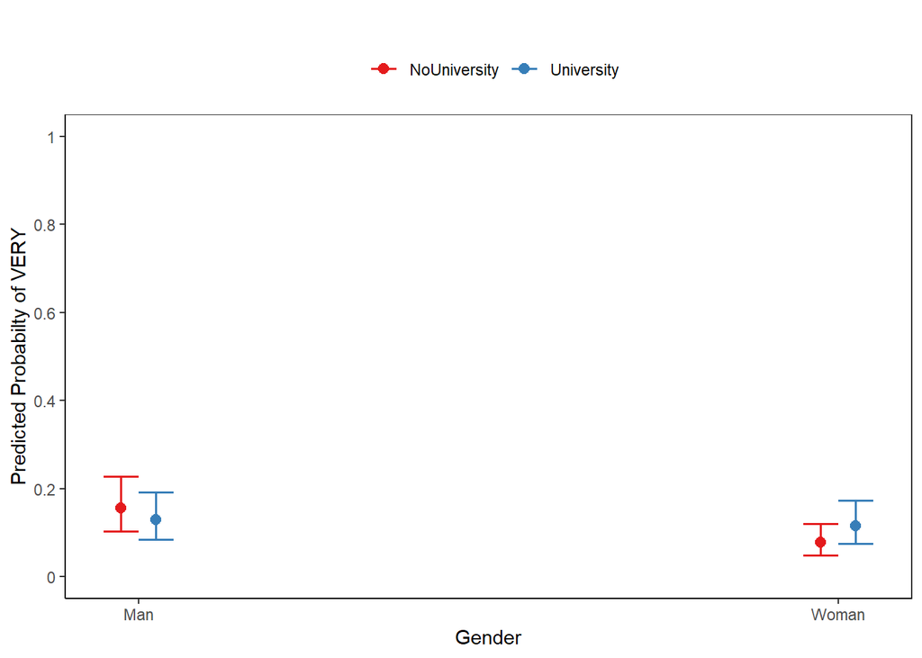

```r
sjPlot::plot_model(m58.glmer, type = "pred",
                   terms = c("Gender", "Education")) +
  theme_bw() +
  theme(legend.position = "top",
        panel.grid.major = element_blank(),
        panel.grid.minor = element_blank(),
        axis.line = element_line(colour = "black"),
        legend.title = element_blank()) +
  scale_y_continuous(name = "Predicted Probabilty of VERY",
                     limits = c(0, 1),
                     breaks = seq(0, 1, .20),
                     labels = seq(0, 1, .20)) +
  labs(title = "") +
  ggsave(file =  here::here("images", "Effect_Gender_Education.png"),
         width = 7.5, height = 15, units = c("cm"),  dpi = 600)
```

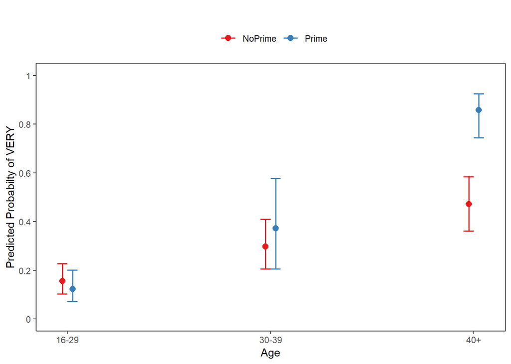

```r
sjPlot::plot_model(m58.glmer, type = "pred", terms = c("Age", "Priming")) +
  theme_bw() +
  theme(legend.position = "top",
        panel.grid.major = element_blank(),
        panel.grid.minor = element_blank(),
        axis.line = element_line(colour = "black"),
        legend.title = element_blank()) +
  scale_y_continuous(name = "Predicted Probabilty of VERY",
                     limits = c(0, 1),
                     breaks = seq(0, 1, .20),
                     labels = seq(0, 1, .20)) +
  labs(title = "") +
  ggsave(file =  here::here("images", "Effect_Age_Priming.png"),
         width = 7.5, height = 15, units = c("cm"),  dpi = 600)
```

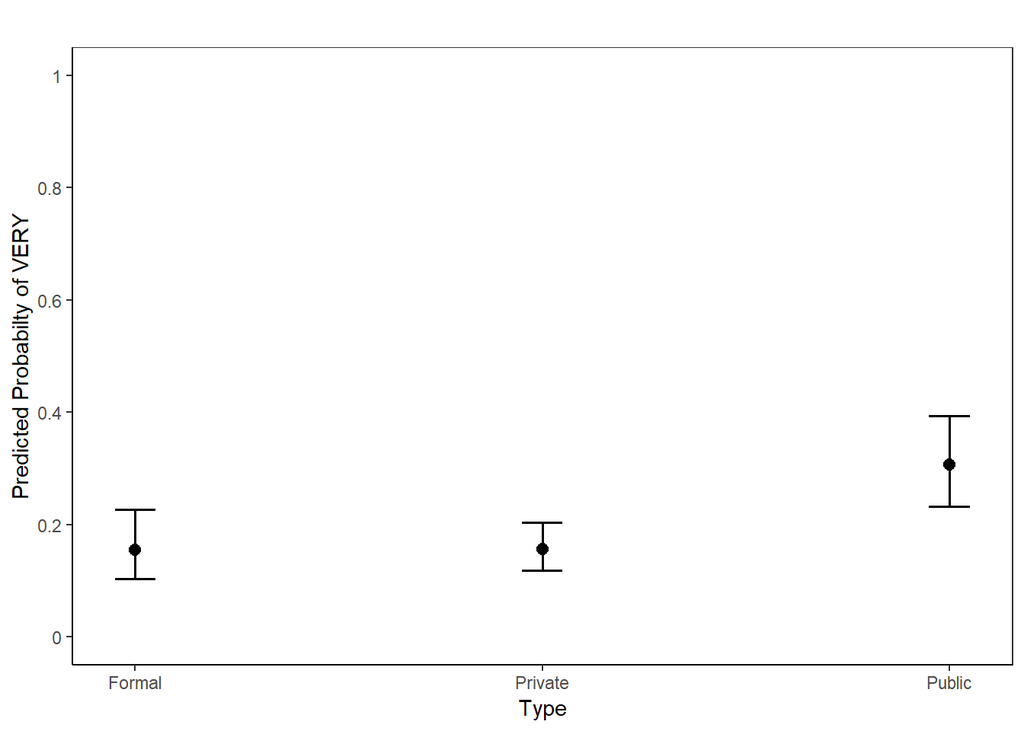

```r
sjPlot::plot_model(m58.glmer, type = "pred", terms = c("Type")) +
  theme_bw() +
  theme(legend.position = "top",
        panel.grid.major = element_blank(),
        panel.grid.minor = element_blank(),
        axis.line = element_line(colour = "black"),
        legend.title = element_blank()) +
  scale_y_continuous(name = "Predicted Probabilty of VERY",
                     limits = c(0, 1),
                     breaks = seq(0, 1, .20),
                     labels = seq(0, 1, .20)) +
  labs(title = "") +
  ggsave(file =  here::here("images", "Effect_Type.png"),
         width = 7.5, height = 13, units = c("cm"),  dpi = 600)
```

```r
randomtb <- ranef(m58.glmer)
rndmadj <- as.vector(unlist(randomtb$`Adjective`))
adj <- as.vector(unlist(rownames(randomtb$`Adjective`)))
rndmadjtb <- data.frame(adj, rndmadj)
colnames(rndmadjtb) <- c("Adjective", "Intercept")
rndmadjtb <- rndmadjtb[order(rndmadjtb$Intercept, decreasing = T),]
# inspect
head(rndmadjtb)
```

```
##      Adjective Intercept
## 131        few  1.361439
## 322      small  1.330405
## 22  attractive  1.265478
## 399   valuable  1.256774
## 36       brave  1.068459
## 259   pleasant  1.032362
```

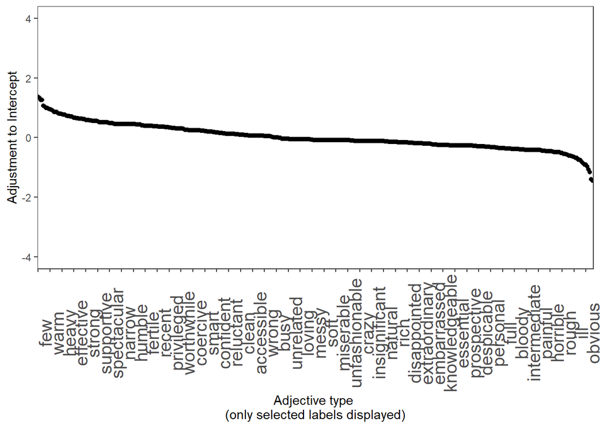

```r
ggplot(rndmadjtb, aes(Adjective, Intercept)) +
  geom_point(aes(reorder(Adjective, -Intercept, fun = Intercept), y=Intercept)) +
  coord_cartesian(ylim = c(-4, 4)) +
  theme_set(theme_bw(base_size = 15)) +
  theme_bw()+
  theme(legend.position="none",
        axis.text.x = element_text(size=15, angle=90),
        panel.grid.major = element_blank(),
        panel.grid.minor = element_blank()) +
  scale_x_discrete(breaks = rndmadjtb$Adjective[seq(1,length(rndmadjtb$Adjective),9)]) +
  labs(x = "Adjective type \n(only selected labels displayed)", y = "Adjustment to Intercept") +
  ggsave(file = here::here("images", "RandomEffects_Adjective.png"),
       height = 5,  width = 7.5,  dpi = 320)
```

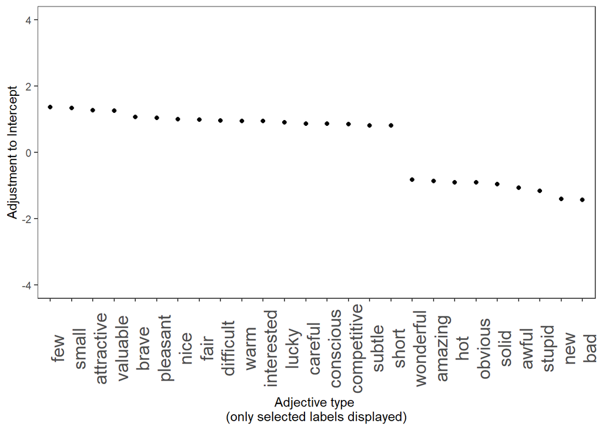

```r
rndmadjtb %>%
  dplyr::filter(Intercept > .8 | Intercept < -.8) %>%
  ggplot(aes(Adjective, Intercept)) +
  geom_point(aes(reorder(Adjective, -Intercept, fun = Intercept), y=Intercept)) +
  coord_cartesian(ylim = c(-4, 4)) +
  theme_bw() +
  theme(legend.position="none",
        axis.text.x = element_text(size=15, angle=90),
        panel.grid.major = element_blank(),
        panel.grid.minor = element_blank()) +
  labs(x = "Adjective type \n(only selected labels displayed)", y = "Adjustment to Intercept") +
  ggsave(file = here::here("images", "RandomEffects_Adjective_redux.png"),
       height = 5,  width = 7.5,  dpi = 320)
```

# Citation & Session Info

Schweinberger, Martin. 2021. *On the waning of forms - a corpus-based analysis of losers in language change (Part 3)*. Brisbane: The University of Queensland. url: https://slcladal.github.io/isle6verynze.html (Version 2021.05.17).

```
@manual{schweinberger2021isle6verynze,
  author = {Schweinberger, Martin},
  title = {On the waning of forms - a corpus-based analysis of losers in language change (Part 3)},
  note = {https://slcladal.github.io/isle6verynze.html},
  year = {2021},
  organization = {The University of Queensland, School of Languages and Cultures},
  address = {Brisbane},
  edition = {2021.05.17}
}
```

Back to top

# References

Chen, Henian, Patricia Cohen, and Sophie Chen. 2010. “How Big Is a Big Odds Ratio? Interpreting the Magnitudes of Odds Ratios in Epidemiological Studies.” *Communications in Statistics—Simulation and Computation* 39 (4): 860–64.